# Author: Suhas Kommalapati M14001928

```python
#Reading the csv again so as to counteract lost data due to droppin null rows.
df3=pd.read_csv(r'C:\Users\Bhanu\Downloads\covidML\Medical_Conditions.csv')
df3
```

|  | YEAR | MEDICAL CONDITION | CHILDREN-COUNT | CHILDREN-PERCENT(%) | ADULTS-COUNT | ADULTS-PERCENT(%) | FEMALES (15-44 YR)-COUNT | FEMALES (15-44 YR)-PERCENT(%) |
| --- | --- | --- | --- | --- | --- | --- | --- | --- |
| 0 | 2020 | Asthma | 300.0 | 13.0 | NaN | 11.8 | NaN | NaN |
| 1 | 2020 | Cardiovascular disease | 127.0 | 5.5 | NaN | 36.8 | NaN | NaN |
| 2 | 2020 | Chronic lung disease | 115.0 | 5.0 | NaN | 20.1 | NaN | NaN |
| 3 | 2020 | Immune suppression | 105.0 | 4.6 | NaN | 10.1 | NaN | NaN |
| 4 | 2020 | Metabolic disease | 125.0 | 5.4 | NaN | 44.2 | NaN | NaN |
| 5 | 2020 | Neurologic disease | 301.0 | 13.1 | NaN | 20.6 | NaN | NaN |
| 6 | 2020 | Other disease | 464.0 | 20.1 | NaN | 11.9 | NaN | NaN |
| 7 | 2020 | No known condition | 1077.0 | 46.8 | NaN | 7.9 | NaN | NaN |
| 8 | 2020 | Autoimmune disease | 10.0 | 0.4 | NaN | 3.1 | NaN | NaN |
| 9 | 2020 | Obesity | 428.0 | 34.8 | NaN | 48.2 | NaN | NaN |
| 10 | 2020 | Pregnancy | NaN | NaN | NaN | NaN | NaN | 29.0 |
| 11 | 2020 | Renal disease | 38.0 | 1.6 | NaN | 17.1 | NaN | NaN |
| 12 | 2020 | Gastrointestinal/liver disease | 41.0 | 1.8 | NaN | 5.3 | NaN | NaN |
| 13 | 2020 | Hypertension | 52.0 | 2.3 | NaN | 59.5 | NaN | NaN |

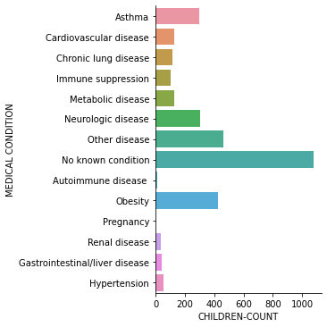

```python
#Medical Condition csv Visualization
#We can understand pre existing conditions  that are leading to more adverse effects in children with COVID.
sns.catplot(x="CHILDREN-COUNT",y="MEDICAL CONDITION",kind='bar',data=df3)
```

```python
print('Obesity, asthama stand out to be the most problematic pre-existing conditions. However a large number of the kids suffer with COVID with or without the pre-existing conditions')
print('Auto immune disorder children are lowest vulnerable groups.')
print('Breathing related problems like asthama, chronic lung diseases seems to be contributing the COVID vulnerabilities.')
```

```
Obesity, asthama stand out to be the most problematic pre-existing conditions. However a large number of the kids suffer with COVID with or without the pre-existing conditions
Auto immune disorder children are lowest vulnerable groups.
Breathing related problems like asthama, chronic lung diseases seems to be contributing the COVID vulnerabilities.
```

```
This graph shows the distribution of how 0-4 year olds fared with covid oer the year in terms of weeks
```

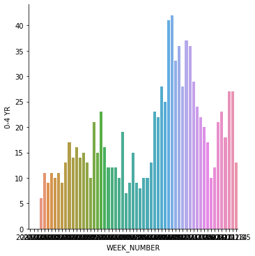

```python
sns.catplot(x="WEEK_NUMBER",y="0-4 YR",kind='bar',data=df2)
print('This graph shows the distribution of how 0-4 year olds fared with covid oer the year in terms of weeks')
```

```
This graph shows the distribution of how 5-17 year olds fared with covid oer the year in terms of weeks
```

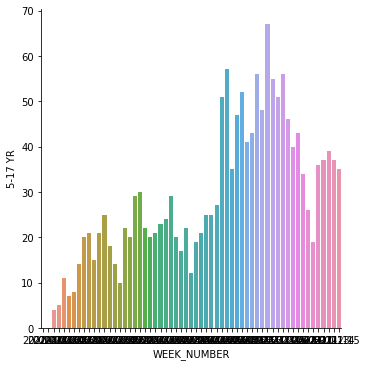

```python
sns.catplot(x="WEEK_NUMBER",y="5-17 YR",kind='bar',data=df2)

print('This graph shows the distribution of how 5-17 year olds fared with covid oer the year in terms of weeks')
```

```
This graph shows the distribution of how 18-49 year olds fared with covid oer the year in terms of weeks
```

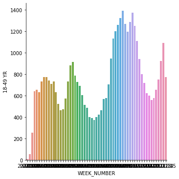

```python
sns.catplot(x="WEEK_NUMBER",y="18-49 YR",kind='bar',data=df2)

print('This graph shows the distribution of how 18-49 year olds fared with covid oer the year in terms of weeks')
```

```
This graph shows the distribution of how 50-64 year olds fared with covid oer the year in terms of weeks
```

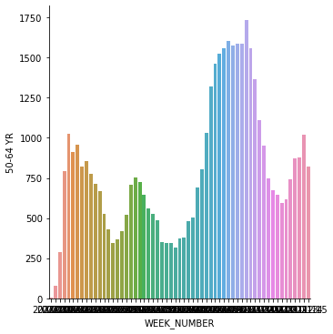

```python
sns.catplot(x="WEEK_NUMBER",y="50-64 YR",kind='bar',data=df2)

print('This graph shows the distribution of how 50-64 year olds fared with covid oer the year in terms of weeks')
```

```
This graph shows the distribution of how 65+ year olds fared with covid oer the year in terms of weeks
```

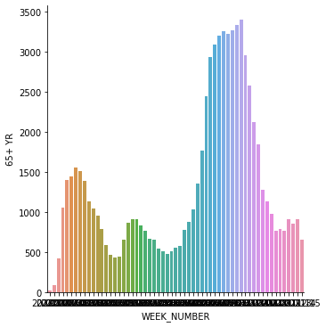

```python
sns.catplot(x="WEEK_NUMBER",y="65+ YR",kind='bar',data=df2)

print('This graph shows the distribution of how 65+ year olds fared with covid oer the year in terms of weeks')
```

# Conclusion

From the visualizations, we can safely say

Obesity, asthama stand out to be the most problematic pre-existing conditions. However a large number of the kids suffer with COVID with or without the pre-existing conditions Auto immune disorder children are lowest vulnerable groups Breathing related problems like asthama, chronic lung diseases seems to be contributing the COVID vulnerabilities. AS Age increase covid cases are also high